# Course Project 1

Filippo D’Ercoli

6/17/2020

## Loading and preprocessing the data

First, I need to read the data into RStudio. A summary of the dataset is reported.

```r
data <- read.csv("activity.csv")
summary(data)
```

```
##      steps                date          interval
##  Min.   :  0.00   2012-10-01:  288   Min.   :   0.0
##  1st Qu.:  0.00   2012-10-02:  288   1st Qu.: 588.8
##  Median :  0.00   2012-10-03:  288   Median :1177.5
##  Mean   : 37.38   2012-10-04:  288   Mean   :1177.5
##  3rd Qu.: 12.00   2012-10-05:  288   3rd Qu.:1766.2
##  Max.   :806.00   2012-10-06:  288   Max.   :2355.0
##  NA's   :2304     (Other)   :15840
```

## What is mean total number of steps taken per day?

I summed the steps taken in each interval of a single day using “tapply”. Then I plotted an histogram and calculated mean and median of the total number of steps taken per day.

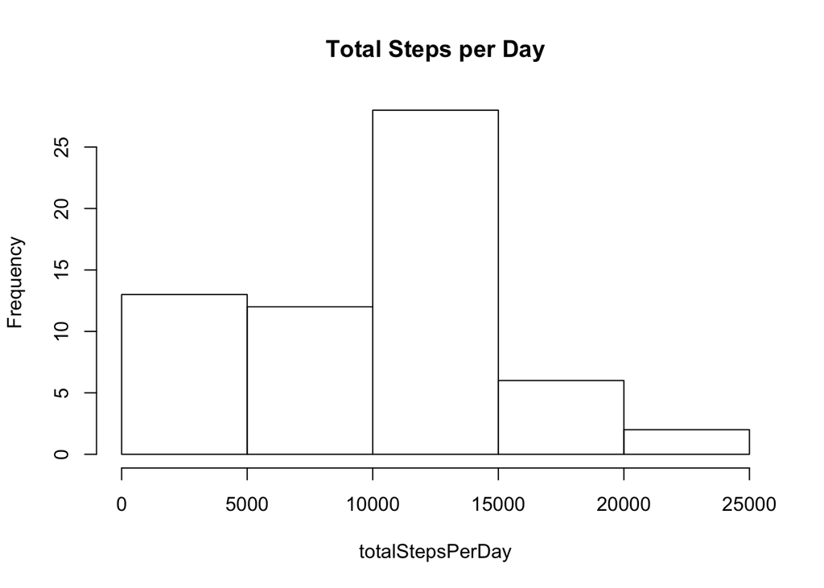

```r
totalStepsPerDay <- tapply(data$steps, data$date, sum, na.rm=TRUE)
hist(totalStepsPerDay, main = "Total Steps per Day")
```

```r
summary(totalStepsPerDay) [4]
```

```
##    Mean
## 9354.23
```

```r
summary(totalStepsPerDay) [3]
```

```
## Median
##  10395
```

## What is the average daily activity pattern?

I grouped the observations by interval and I calculated the mean of each group, obtaining a daily activity pattern. Then I plotted this pattern versus the intervals.

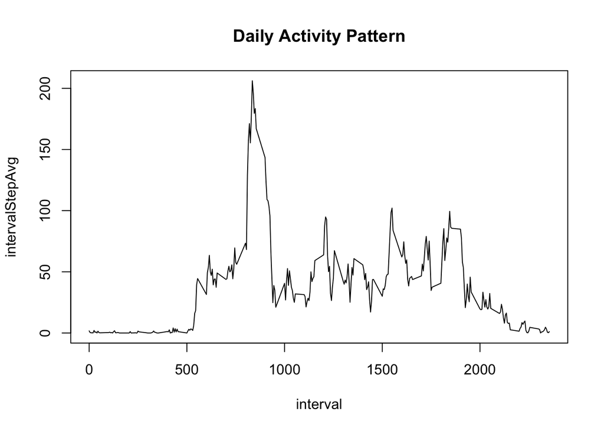

```r
dailyPattern <- group_by(data, interval) %>% summarise(intervalStepAvg = mean(steps, na.rm=TRUE))
with(dailyPattern, plot(interval, intervalStepAvg, type = "l"))
title(main = "Daily Activity Pattern")
```

```r
maxSteps <- max(dailyPattern$intervalStepAvg)
maxInt <- subset(dailyPattern, dailyPattern$intervalStepAvg == maxSteps) [1]
```

The interval which on average registers the maximum number of steps is 835.

## Imputing missing values

```r
totalNA <- sum(is.na(data$steps))
```

The total number of missing values is 2304. A suitable strategy for fill them in could be using the mean over the same 5-minute interval. A new dataset “imputedData” with the imputed values was created. Then I plotted the histogram of the new dataset and calculated again mean and median.

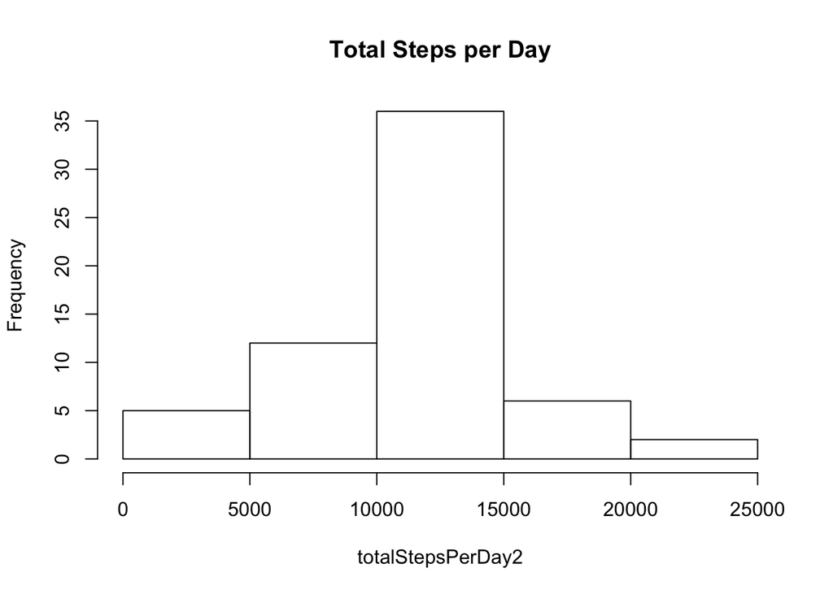

```r
imputedData <- data
for (i in 1:length(data$steps)) {
  if (is.na(data$steps [i])) {
    if (i%%288 != 0) {
      imputedData$steps [i] <- dailyPattern$intervalStepAvg [i%%288]
    }
    else imputedData$steps [i] <- dailyPattern$intervalStepAvg [288]
  }
}
totalStepsPerDay2 <- tapply(imputedData$steps, imputedData$date, sum, na.rm=TRUE)
hist(totalStepsPerDay2, main = "Total Steps per Day")
```

```r
summary(totalStepsPerDay2) [4]
```

```
##     Mean
## 10766.19
```

```r
summary(totalStepsPerDay2) [3]
```

```
##   Median
## 10766.19
```

Imputing the data gives the histogram a more regular shape. The median is almost the same, while the mean increases a bit and happens to be equal to the median.

## Are there differences in activity patterns between weekdays and weekends?

I created a new variable called “dayLevel”. It is a factor variable with 2 levels which identify weekdays and weekends.

```r
weekday <- weekdays(as.POSIXct.Date(imputedData$date))
weekData <- mutate(imputedData, dayLevel = rep("weekday", length(imputedData$date)))
for (i in 1:length(imputedData$date)) {
  if (weekday[i] == "Saturday" || weekday[i] == "Sunday") {
    weekData$dayLevel[i] <- "weekend"
  }
}
```

Then I grouped the observations by interval and dayLevel, calculated the average steps taken per interval and plotted it.

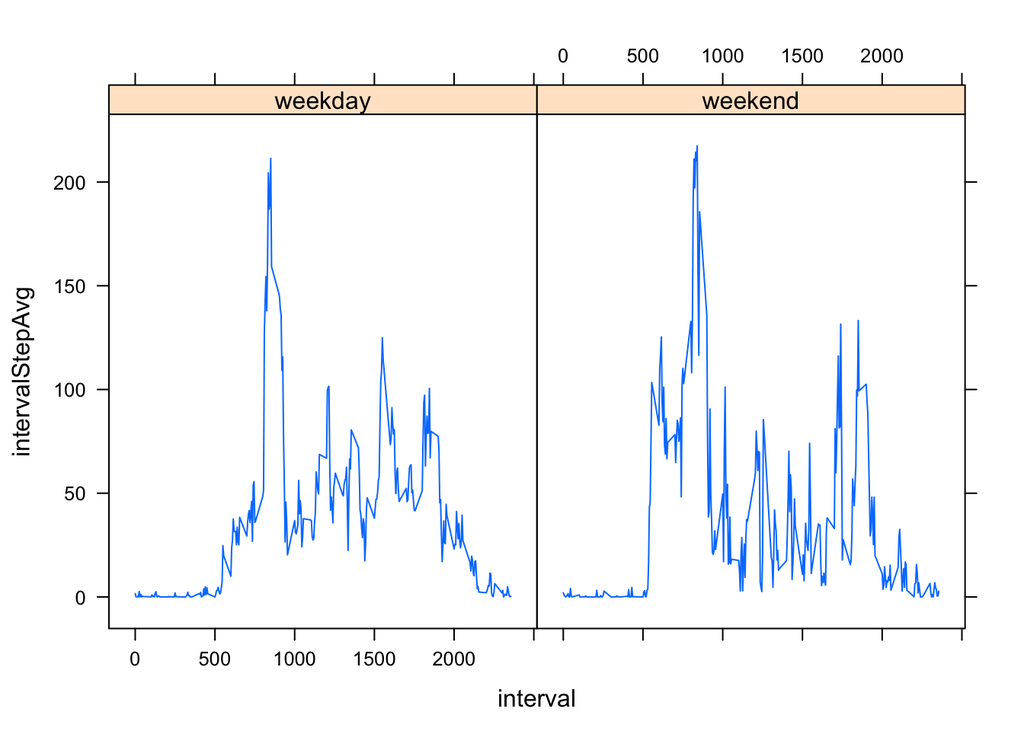

```r
weeklyPattern <- group_by(weekData, interval, dayLevel) %>% summarise(intervalStepAvg = mean(steps, na.rm=TRUE))
xyplot(intervalStepAvg ~ interval | dayLevel, weeklyPattern, type = "l")
```